# Instructions

## Question 4 (2 pts)

Suppose you think the association between arrival delay and journey time (i.e., the slope of journey time) may change from year to year. Fit a linear model below which would allow for that. For this problem, you **do not** need to consider adjusting for other variables in the model.

```r
train_data$year
```

[output not shown]

[output cut: 2322 more lines]

```r
mod4 = lm(avg_delay_all_arriving ~ journey_time_avg * year, data = train_data)
mod4
```

```
##
## Call:
## lm(formula = avg_delay_all_arriving ~ journey_time_avg * year,
##     data = train_data)
##
## Coefficients:
##               (Intercept)           journey_time_avg
##                  0.655473                   0.022534
##                  year2016                   year2017
##                  0.485688                   1.549553
##                  year2018  journey_time_avg:year2016
##                  2.868051                  -0.002177
## journey_time_avg:year2017  journey_time_avg:year2018
##                 -0.002768                  -0.001038
```

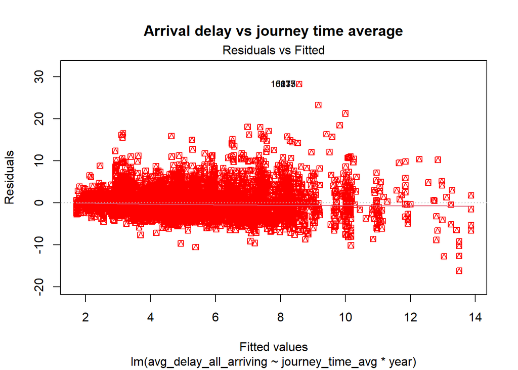

```r
plot(mod4, which = 1,
main = "Arrival delay vs journey time average",
col = "red", pch = 14)
```

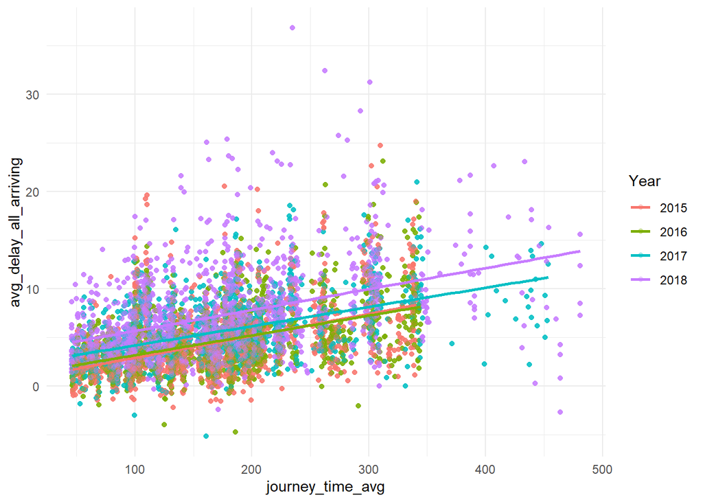

```r
ggplot(train_data, aes(x= journey_time_avg, y = avg_delay_all_arriving, color = factor(year))) + geom_point(alpha =0.3) + geom_smooth(method = "lm", se = FALSE)+ labs(color = "Year") + theme_minimal()
```

### Question 4 Answer

I created two different plots for this question. I do not like using plot as much as I do like using ggplot. With ggplot I feel like I can do more with the scatterplots and lay lines over top to be able to see linear relationships. The utility of the ggplot is to visualize the difference between each year for the association of journey time and arrival delay. This ggplot does show us that there is a difference in the association between arrival delay and journey time for each year, with the year 2018 having the most variable looking data, you can see some outliers for that year compared to other years. The plot() does show us the fitted vs. residual values, that is useful for determining if we have a model that fits well (if the scatter plot is around 0, it indicates that the model has a good fit.)

## Question 5 (3 pts)

Below, we fit a model which includes the covariates journey time, average departing delay and month. Suppose we want to test if the average arrival delay is associated with month after adjusting for journey time and average departure delay. For this problem, you don’t need to consider interaction terms and you don’t need to include other covariates. Describe how you would test this hypothesis. You don’t need to actually perform any calculations or write any code, but specify which function in R you would use and be specific about what the inputs would be.

```r
mod_year <- lm(avg_delay_all_arriving ~ journey_time_avg + avg_delay_all_departing + month,
               data = train_data)
summary(mod_year)
```

```
##
## Call:
## lm(formula = avg_delay_all_arriving ~ journey_time_avg + avg_delay_all_departing +
##     month, data = train_data)
##
## Residuals:
##      Min       1Q   Median       3Q      Max
## -12.3284  -1.6465  -0.1308   1.3595  21.8094
##
## Coefficients:
##                           Estimate Std. Error t value Pr(>|t|)
## (Intercept)             -0.8915362  0.0625821 -14.246  < 2e-16 ***
## journey_time_avg         0.0221554  0.0001925 115.083  < 2e-16 ***
## avg_delay_all_departing  0.7985477  0.0067729 117.903  < 2e-16 ***
## month2                   0.4563799  0.0735195   6.208 5.44e-10 ***
## month3                  -0.4736258  0.0734958  -6.444 1.18e-10 ***
## month4                  -0.0804941  0.0735030  -1.095    0.273
## month5                   0.3251169  0.0735458   4.421 9.87e-06 ***
## month6                   1.8615067  0.0739347  25.178  < 2e-16 ***
## month7                   1.9471457  0.0742472  26.225  < 2e-16 ***
## month8                   0.7529611  0.0737336  10.212  < 2e-16 ***
## month9                   0.6157711  0.0735352   8.374  < 2e-16 ***
## month10                  0.9324276  0.0734938  12.687  < 2e-16 ***
## month11                  1.2922029  0.0736160  17.553  < 2e-16 ***
## month12                  0.1396042  0.0810379   1.723    0.085 .
## ---
## Signif. codes:  0 '***' 0.001 '**' 0.01 '*' 0.05 '.' 0.1 ' ' 1
##
## Residual standard error: 2.748 on 32686 degrees of freedom
## Multiple R-squared:  0.4892, Adjusted R-squared:  0.489
## F-statistic:  2408 on 13 and 32686 DF,  p-value: < 2.2e-16
```

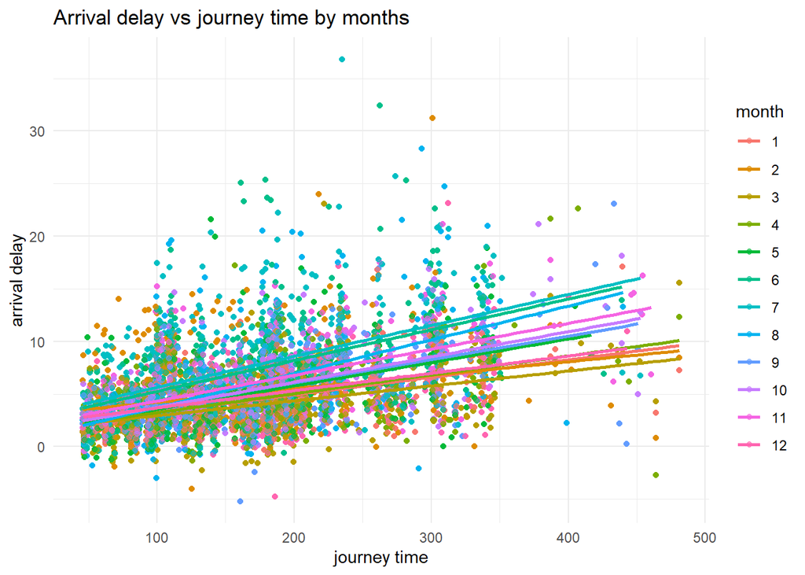

```r
ggplot(train_data, aes(x = journey_time_avg, y = avg_delay_all_arriving, color = factor(month))) + geom_point(alpha = 0.6) + geom_smooth(method = "lm", se = FALSE) + labs(color = "month", title = "Arrival delay vs journey time by months", x = "journey time", y = "arrival delay")  + theme_minimal()
```

#### Question 5 answer I used ggplot to make the map. You said we didn’t have to do the actual code, but I needed to visualize. I like using ggplot like I mentioned previously because I like to be able to color code each data point as a third variable. To perform hypothesis testing for this linear model the summary() gives us the estimate, std error, t-value, and p-value. The t-value tells us if a predictor has an effect or not within the model. You can see from our output, that the months 6,7,11 have the greatest effect for this model, and that is supported by their corresponding p-values.

## Question 6 (2 pt)

Suppose we fit the model below where we have used the log of journey_time_avg. Write 1 sentence interpreting the coefficient for journey time.

```r
mod_log <- lm(avg_delay_all_arriving ~ log(journey_time_avg),
              data = train_data)
summary(mod_log)
```

```
##
## Call:
## lm(formula = avg_delay_all_arriving ~ log(journey_time_avg),
##     data = train_data)
##
## Residuals:
##      Min       1Q   Median       3Q      Max
## -11.8915  -2.2847  -0.4961   1.5921  29.8838
##
## Coefficients:
##                        Estimate Std. Error t value Pr(>|t|)
## (Intercept)           -11.06500    0.19401  -57.03   <2e-16 ***
## log(journey_time_avg)   3.29684    0.03868   85.23   <2e-16 ***
## ---
## Signif. codes:  0 '***' 0.001 '**' 0.01 '*' 0.05 '.' 0.1 ' ' 1
##
## Residual standard error: 3.477 on 32698 degrees of freedom
## Multiple R-squared:  0.1818, Adjusted R-squared:  0.1817
## F-statistic:  7264 on 1 and 32698 DF,  p-value: < 2.2e-16
```

#### Question 6 answer

# Module 4 and 5

## Question 7 (3 pts)

In the model you fit in Question 1, each observation in the dataset corresponds to a specific route observed in a specific month and year. Thus each route appears in the data multiple times. Explain why this might violate an assumption for linear regression. How could you fix this? If your suggestion involves additional covariates or a different modeling assumption, be specific about what you mean (i.e., say what covariates would you include, or what model you would fit). There is more than 1 reasonable answer for this question, but just pick one.

#### Question 7 answer

Because we have repeating data for the same route - a linear regression model isn’t the best fit because this model type works with non-repeating data. We violate the independence assumption because the data points are NOT independent if they are repeated sampling of the same route - observations from the same source (route), will have correlated errors. A model choice that would fit better is a linear mixed effects model - this is because this model allows for repeating data in this case, multiple observations of the same route. Linear mixed effects model works well with repeat sampling data, clustered observations, and hierarchical data.

## Question 8 (3 pts)

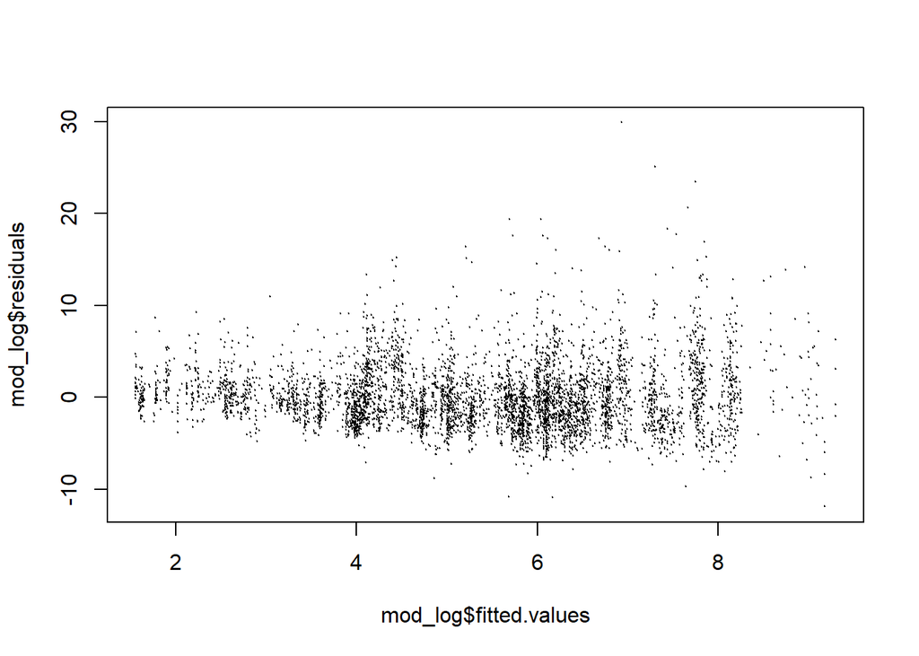

#### Question 8 answer

Model-based errors are using the assumptions of the model that you created - so it will be assume homoscedastic data if you are using a linear model. The robust standard errors is using the residuals from the model you create to then calculate the variability of that specific data. Robust standard errors is more specific to the actual data you are working with compared to model-based errors is making MORE assumptions based on the assumptions that they assume based on linear models, etc.

## Question 9 (3 pts)

Suppose you are taking a train tomorrow from Lille to Paris Nord and want to predict the delay in arrival. You want to be very sure about the prediction, so you gather data for 1000 different variables you think might be relevant (temperature, whether it is raining, GDP of France per month/year, the win/loss record of the soccer team in Lille, etc). You then regress average arrival delay onto all of those variables, and use it to predict the arrival delay for tomorrow’s train. Explain why this might not give a good prediction. What might you do instead? 2-3 sentences for this answer is fine.

#### Question 9 answer

Some of the variables will most likely be related and not independent, so having multiple variables that are related can create a model that is overfitted - this is when data are multicollinear. Also having 1000 variables is a lot and can create a lot of extra noise for the model and might give you a less realistic prediction of your delay in arrival. You are unable to determine for sure which variables are actually creating the most impact to your model.

# Module 6

For the following questions, suppose we are analyzing data for Big Red Airlines, Cornell’s latest idea for getting people to and from Ithaca. The dependent variable is whether or not a flight took off on time. In the variable: 1 indicates that the flight took off on time, 0 indicates that it was delayed. The covariates we have recorded include Temperature (in degrees), TimeOfDay (Evening, Midday, Morning), and Rain (FALSE, TRUE).

```r
airlineData <- read.csv("https://raw.githubusercontent.com/ysamwang/btry6020_sp22/main/lab11/airline.csv")
names(airlineData)
```

```
## [1] "OnTime"      "Temperature" "TimeOfDay"   "Rain"
```

## Question 10 (2 pts)

What is the appropriate type of regression for modeling the binary data? What is being predicted by the linear model we are fitting? i.e., if the model we set up is
$$? = b_0 + b_1
X_{1,i} + b_2 X_{2,i} \ldots$$
what is on the left side of the equation (you can write it out in words instead of typing out the math)?.

#### Question 10 answer

Appropriate type of regression for binary data is logistic regression. Logistic regression is the best for categorical data that has a binary outcome. On the left side of the equation above, would be our outcome of did the flight took off on time (yes (1)/no (0)).

## Question 11 (2 pts)

```r
mod <- glm(OnTime ~ Temperature + TimeOfDay + Rain,
           data = airlineData, family = "binomial")
summary(mod)
```

```
##
## Call:
## glm(formula = OnTime ~ Temperature + TimeOfDay + Rain, family = "binomial",
##     data = airlineData)
##
## Coefficients:
##                  Estimate Std. Error z value Pr(>|z|)
## (Intercept)       1.46094    0.37880   3.857 0.000115 ***
## Temperature      -0.05248    0.00652  -8.050 8.29e-16 ***
## TimeOfDayMidday   0.18066    0.22978   0.786 0.431717
## TimeOfDayMorning -0.59611    0.25310  -2.355 0.018511 *
## RainTRUE         -0.52725    0.19977  -2.639 0.008308 **
## ---
## Signif. codes:  0 '***' 0.001 '**' 0.01 '*' 0.05 '.' 0.1 ' ' 1
##
## (Dispersion parameter for binomial family taken to be 1)
##
##     Null deviance: 765.46  on 892  degrees of freedom
## Residual deviance: 671.25  on 888  degrees of freedom
## AIC: 681.25
##
## Number of Fisher Scoring iterations: 5
```

#### Question 11 answer

# Final Project (30 pts)

## Introduction

This final project is designed to demonstrate your mastery of linear regression techniques on real-world data. You will apply the theoretical concepts we’ve covered in class to a dataset of your choice, perform a comprehensive analysis, and present your findings in a professional format suitable for showcasing to potential employers.

## Objectives

By completing this project, you will:

- Apply linear regression techniques to solve real-world problems
- Demonstrate your ability to verify and address regression assumptions
- Perform meaningful feature selection and hypothesis testing
- Communicate the practical significance of your statistical findings
- Create a professional portfolio piece for future employment opportunities

## Project Requirements

### Dataset Selection

1. Choose a dataset from Kaggle
2. Your dataset must have a continuous target variable suitable for linear regression
3. The dataset should contain multiple potential predictor variables
4. Choose a dataset that interests you and has meaningful real-world applications

## The following is penguin data. This has different species of penguins, the size based on species, the island they originate, sex, etc.

```r
penguins_size = read.csv("C:/Users/tjw237/OneDrive - Cornell University/Documents/STATS 2- BTRY 6020/Final project/penguins_size.csv")
```

## Identifying penguins based on different predictor variables: (Culmen is the upper ridge of the bill of a penguin.) Species, Island, Culmen length in mm, culmen depth in mm, flipper length in mm, body mass in grams, and sex. Penguins are a species of interest because many penguins live in areas that are greatly impacted by climate change and use of natural resources. Identifying how to classify penguins based on species, and identifying species characteristics is important to be able to monitor species specific changes.

### Analysis Requirements

Your analysis must include the following components:

#### Exploratory Data Analysis

- Summary statistics of variables
- Visualization of distributions and relationships
- Identification of missing values and outliers
- Data cleaning and preprocessing steps

#### Regression Assumptions Verification

- Linearity assessment
- Normality of residuals
- Homoscedasticity (constant variance of residuals)
- Independence of observations
- Multicollinearity assessment

#### Assumption Violation Handling

- Apply appropriate transformations when assumptions are violated
- Document your approach to each violation
- Compare models before and after corrections

#### Variable Selection & Hypothesis Testing

- Implement at least two different variable selection techniques
- Perform hypothesis tests on coefficients
- Assess model performance with metrics (R², adjusted R², RMSE, etc.)
- Validate your model using appropriate cross-validation techniques

#### Feature Impact Analysis

- Quantify and interpret the impact of each feature on the target
- Provide confidence intervals for significant coefficients
- Explain the practical significance of your findings in the context of the dataset

```r
table(penguins_size$species, penguins_size$body_mass_g, penguins_size$island)
```

[output not shown]

[output cut: 73 more lines]

[output not shown]

```r
##Sorting penguins by island

Biscoe_peng = subset(penguins_size, island == "Biscoe")
Biscoe_peng
```

[output not shown]

[output cut: 323 more lines]

```r
Torg_peng = subset(penguins_size, island == "Torgersen")
Torg_peng
```

[output not shown]

[output cut: 91 more lines]

```r
Dream_peng = subset(penguins_size, island =="Dream")
Dream_peng
```

[output not shown]

[output cut: 235 more lines]

```r
##Sorting penguins by species

Adelie_spec = subset(penguins_size, species == "Adelie")
Adelie_spec
```

[output not shown]

[output cut: 291 more lines]

```r
Gentoo_spec = subset(penguins_size, species =="Gentoo")
Gentoo_spec
```

```
##     species island culmen_length_mm culmen_depth_mm flipper_length_mm
## 221  Gentoo Biscoe             46.1            13.2               211
## 222  Gentoo Biscoe             50.0            16.3               230
## 223  Gentoo Biscoe             48.7            14.1               210
## 224  Gentoo Biscoe             50.0            15.2               218
## 225  Gentoo Biscoe             47.6            14.5               215
## 226  Gentoo Biscoe             46.5            13.5               210
## 227  Gentoo Biscoe             45.4            14.6               211
## 228  Gentoo Biscoe             46.7            15.3               219
## 229  Gentoo Biscoe             43.3            13.4               209
## 230  Gentoo Biscoe             46.8            15.4               215
## 231  Gentoo Biscoe             40.9            13.7               214
## 232  Gentoo Biscoe             49.0            16.1               216
## 233  Gentoo Biscoe             45.5            13.7               214
## 234  Gentoo Biscoe             48.4            14.6               213
```

[output cut: 235 more lines]

```r
Chinstrap_spec = subset(penguins_size, species == "Chinstrap")
Chinstrap_spec
```

```
##       species island culmen_length_mm culmen_depth_mm flipper_length_mm
## 153 Chinstrap  Dream             46.5            17.9               192
## 154 Chinstrap  Dream             50.0            19.5               196
## 155 Chinstrap  Dream             51.3            19.2               193
## 156 Chinstrap  Dream             45.4            18.7               188
## 157 Chinstrap  Dream             52.7            19.8               197
## 158 Chinstrap  Dream             45.2            17.8               198
## 159 Chinstrap  Dream             46.1            18.2               178
## 160 Chinstrap  Dream             51.3            18.2               197
## 161 Chinstrap  Dream             46.0            18.9               195
## 162 Chinstrap  Dream             51.3            19.9               198
## 163 Chinstrap  Dream             46.6            17.8               193
## 164 Chinstrap  Dream             51.7            20.3               194
## 165 Chinstrap  Dream             47.0            17.3               185
## 166 Chinstrap  Dream             52.0            18.1               201
```

[output cut: 123 more lines]

```r
penguin_size_spec = lm(body_mass_g ~ species, data = penguins_size)
summary(penguin_size_spec)
```

```
##
## Call:
## lm(formula = body_mass_g ~ species, data = penguins_size)
##
## Residuals:
##      Min       1Q   Median       3Q      Max
## -1126.02  -333.09   -33.09   316.91  1223.98
##
## Coefficients:
##                  Estimate Std. Error t value Pr(>|t|)
## (Intercept)       3700.66      37.62   98.37   <2e-16 ***
## speciesChinstrap    32.43      67.51    0.48    0.631
## speciesGentoo     1375.35      56.15   24.50   <2e-16 ***
## ---
## Signif. codes:  0 '***' 0.001 '**' 0.01 '*' 0.05 '.' 0.1 ' ' 1
##
## Residual standard error: 462.3 on 339 degrees of freedom
##   (2 observations deleted due to missingness)
## Multiple R-squared:  0.6697, Adjusted R-squared:  0.6677
## F-statistic: 343.6 on 2 and 339 DF,  p-value: < 2.2e-16
```

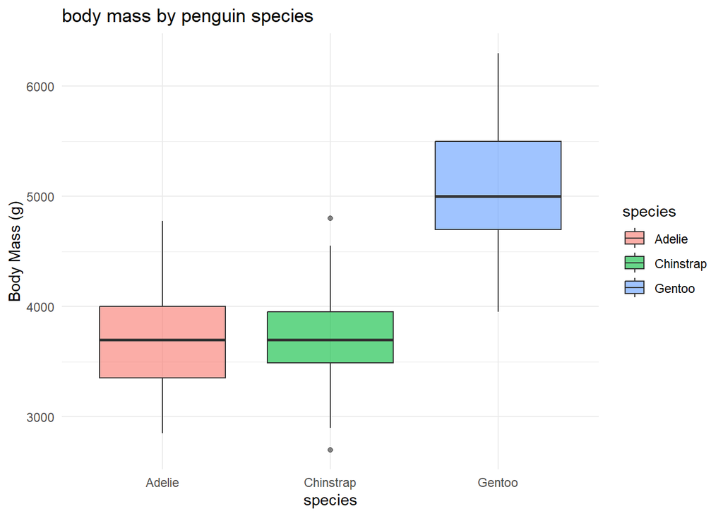

```r
## boxplot of the species of penguin and the body mass
ggplot(penguins_size, aes(x = species, y = body_mass_g, fill = species)) +
  geom_boxplot(alpha = 0.6) +
  labs(title = "body mass by penguin species",
       y= "Body Mass (g)") +
  theme_minimal()
```

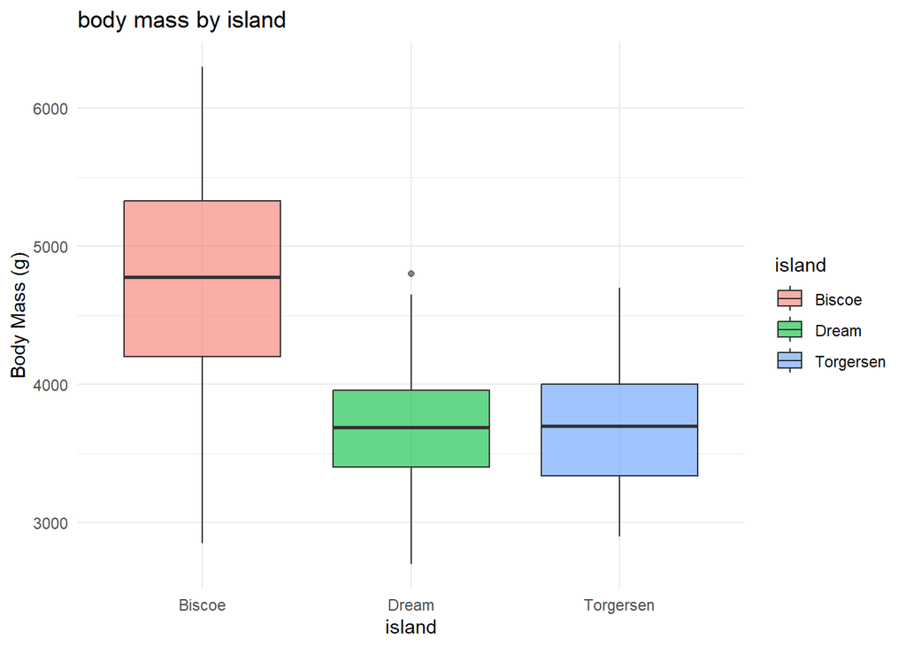

```r
## you can see that for the Chinstrap species there are two outliers in that group.

#Boxplot of the body mass by island
penguin_island_plot = ggplot(penguins_size, aes(x = island, y = body_mass_g, fill = island)) +
  geom_boxplot(alpha = 0.6) +
  labs(title = "body mass by island",
       y= "Body Mass (g)") +
  theme_minimal()
penguin_island_plot
```

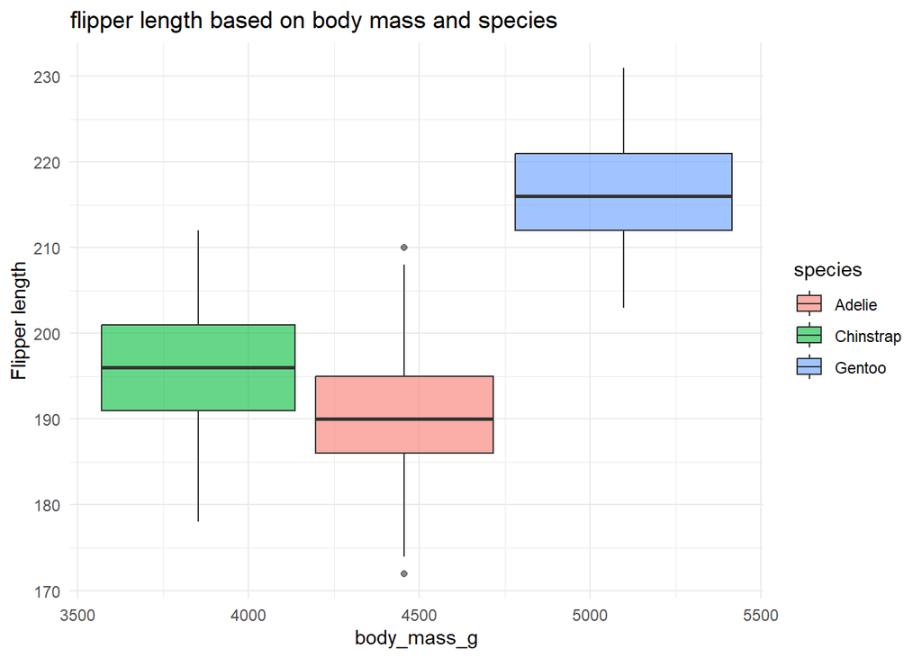

```r
#Penguin flipper length by body mass and species
ggplot(penguins_size, aes(x = body_mass_g, y = flipper_length_mm, fill = species)) +
  geom_boxplot(alpha = 0.6) +
  labs(title = "flipper length based on body mass and species",
       y= "Flipper length") +
  theme_minimal()
```

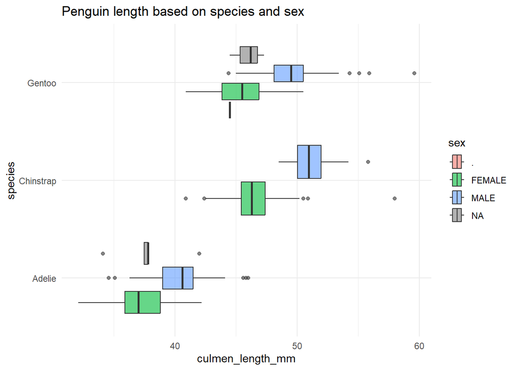

```r
#Length of penguin by species and sex
ggplot(penguins_size, aes(x = culmen_length_mm, y = species, fill = sex)) +
  geom_boxplot(alpha = 0.6) +
  labs(title = "Penguin length based on species and sex",
       y= "species") +
  theme_minimal()
```

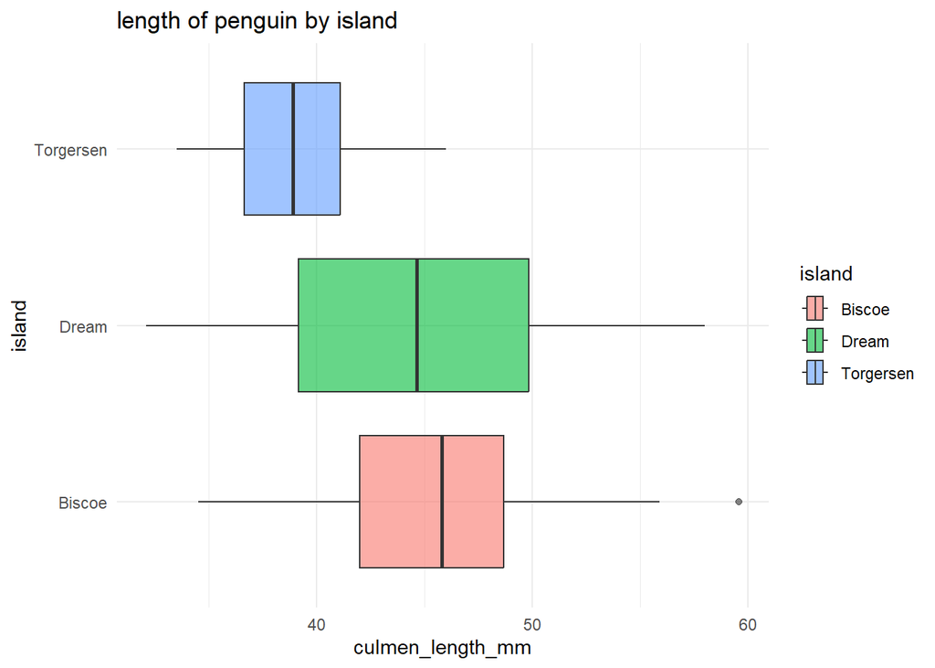

```r
#length of penguin by island
ggplot(penguins_size, aes(x = culmen_length_mm, y = island, fill = island)) +
  geom_boxplot(alpha = 0.6) +
  labs(title = "length of penguin by island",
       y= "island") +
  theme_minimal()
```

```r
##For some of the plots there is a warning error that comes with the plots - that is because some of the data is either outside of range, or does not fit the scale - this can be due to typos, outliers, missing data, etc.

## needing all the data to be numeric - I have to recode the predictors that are categorical into numerical based predictors.

library("dplyr")
levels(penguins_size$species)
```

[output not shown]

```r
levels(penguins_size$island)
```

[output not shown]

```r
levels(penguins_size$sex)
```

[output not shown]

```r
pengsize_species = recode(penguins_size$species,
"Adelie" = 1, "Chinstrap" = 2, "Gentoo'" = 3)
pengsize_island = recode(penguins_size$island,
                         "Biscoe" = 1,
                         "Dream" = 2,
                         "Torgersen" = 3)

pengsize_sex = recode(penguins_size$sex,
                      "FEMALE" = 1,
                      "MALE" = 2)
##model of penguin species based on the other variables: island, culmen length, culmen depth, flipper length, body mass, and sex

lin_mod_penguin = lm(pengsize_species ~ pengsize_island + penguins_size$culmen_length_mm + penguins_size$culmen_depth_mm + penguins_size$flipper_length_mm + penguins_size$body_mass_g + pengsize_sex)
lin_mod_penguin
```

```
##
## Call:
## lm(formula = pengsize_species ~ pengsize_island + penguins_size$culmen_length_mm +
##     penguins_size$culmen_depth_mm + penguins_size$flipper_length_mm +
##     penguins_size$body_mass_g + pengsize_sex)
##
## Coefficients:
##                     (Intercept)                  pengsize_island
##                      -1.6972465                       -0.0104411
##  penguins_size$culmen_length_mm    penguins_size$culmen_depth_mm
##                       0.0798823                       -0.0166056
## penguins_size$flipper_length_mm        penguins_size$body_mass_g
##                       0.0036062                       -0.0001007
##                    pengsize_sex
##                      -0.2215605
```

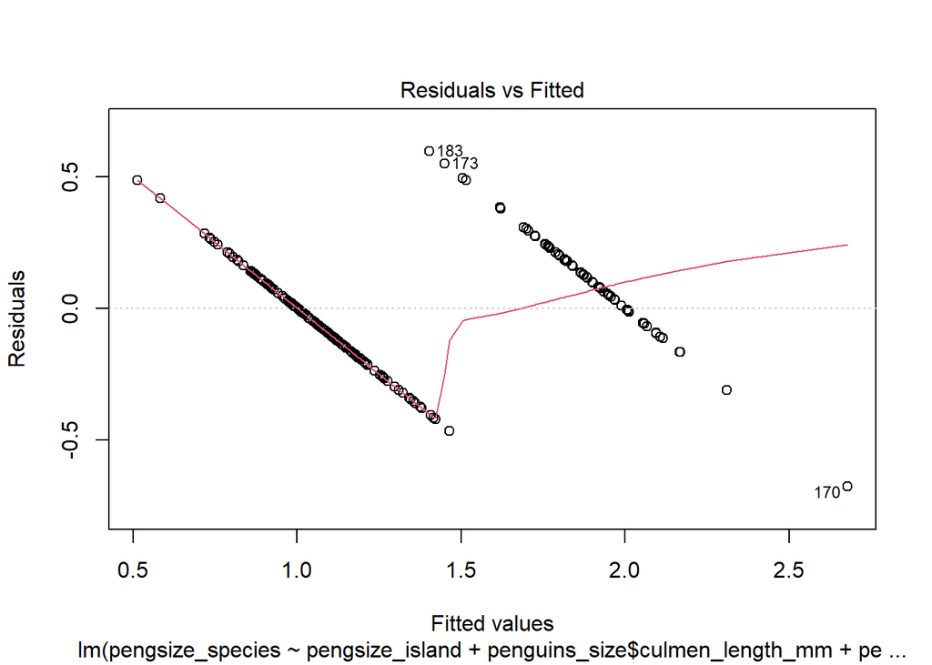

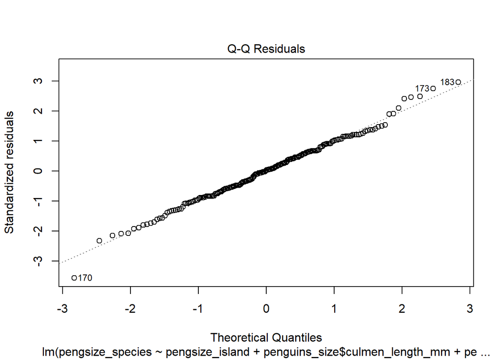

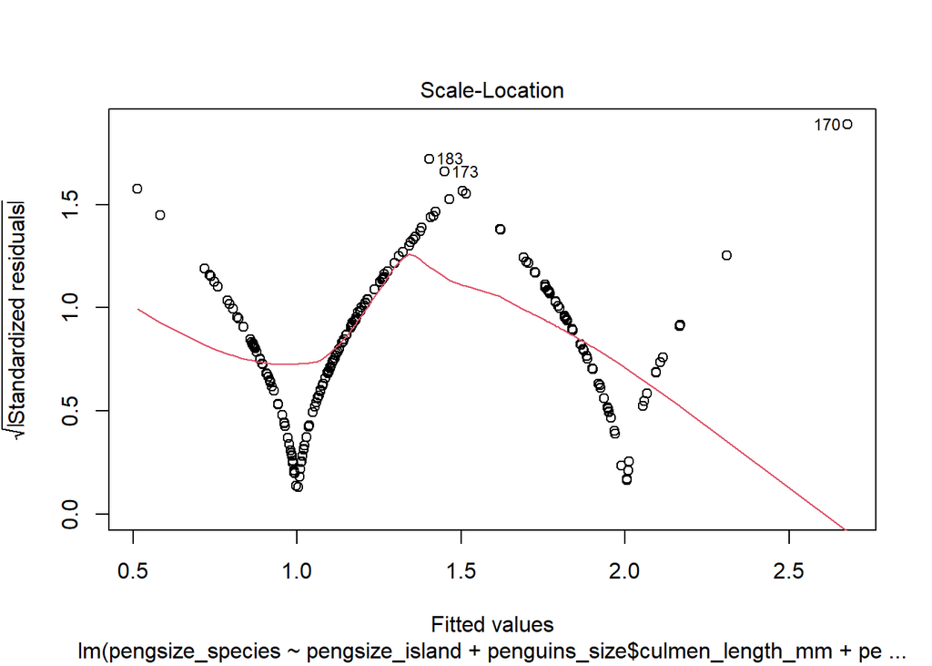

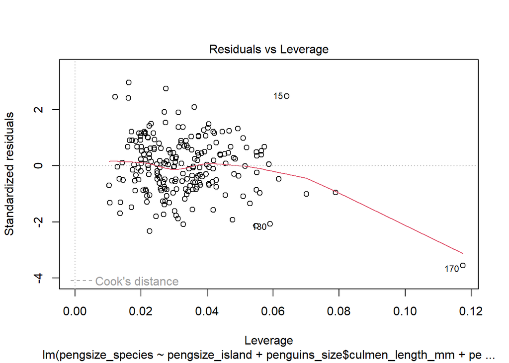

```r
plot(lin_mod_penguin)
```

```r
##model of penguin sex based on the other variables:island, culmen length, culmen depth, flipper length, body mass, and species

lin_mod_pengsex = lm(pengsize_sex ~ pengsize_species + pengsize_island + penguins_size$culmen_length_mm + penguins_size$culmen_depth_mm + penguins_size$flipper_length_mm + penguins_size$body_mass_g)

lin_mod_pengsex
```

```
##
## Call:
## lm(formula = pengsize_sex ~ pengsize_species + pengsize_island +
##     penguins_size$culmen_length_mm + penguins_size$culmen_depth_mm +
##     penguins_size$flipper_length_mm + penguins_size$body_mass_g)
##
## Coefficients:
##                     (Intercept)                 pengsize_species
##                      -4.0059385                       -0.5407087
##                 pengsize_island   penguins_size$culmen_length_mm
##                      -0.0153845                        0.0507814
##   penguins_size$culmen_depth_mm  penguins_size$flipper_length_mm
##                       0.1213979                        0.0021953
##       penguins_size$body_mass_g
##                       0.0003944
```

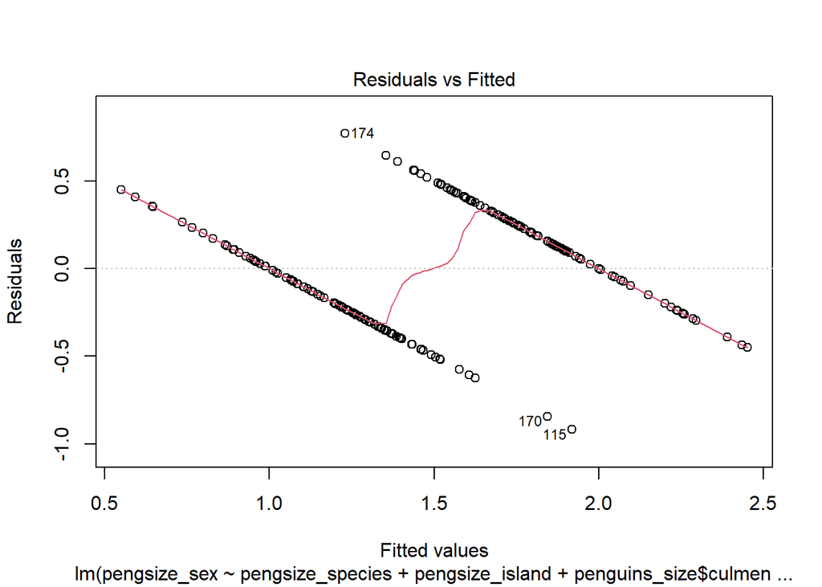

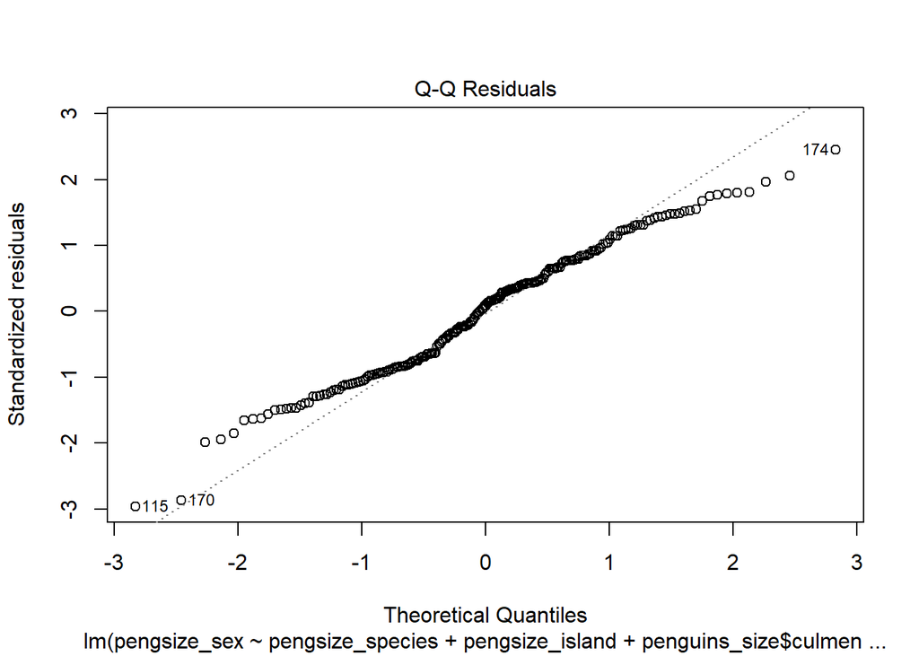

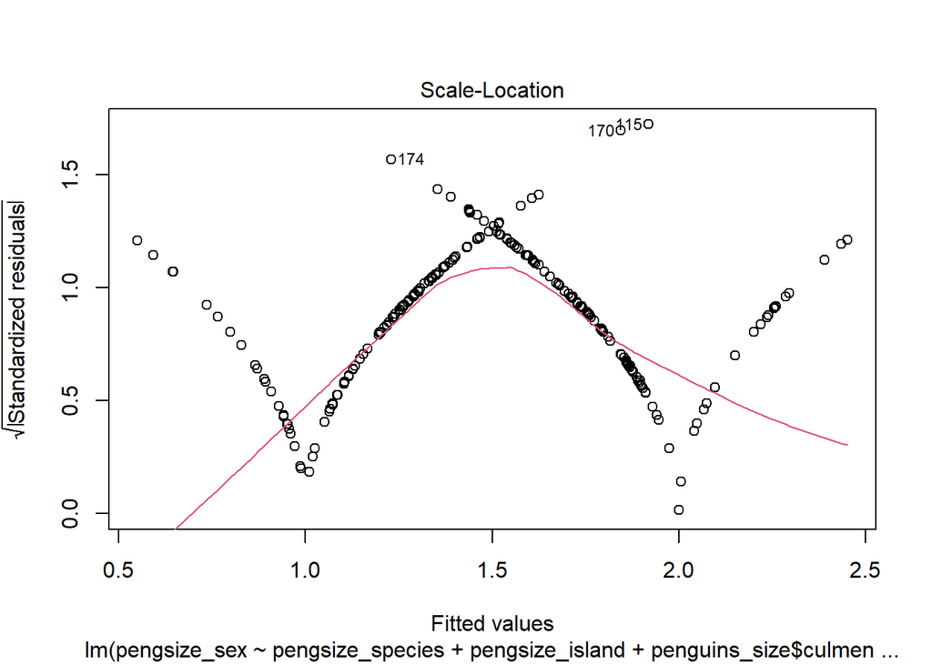

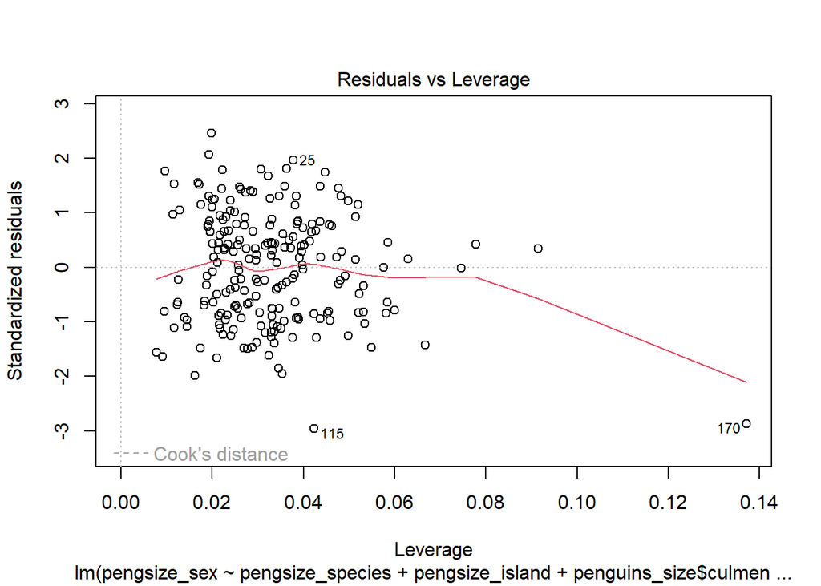

```r
plot(lin_mod_pengsex)
```

```r
##model of penguin species based on flipper length

linmodspecies = lm(pengsize_species ~ penguins_size$flipper_length_mm)
linmodspecies
```

```
##
## Call:
## lm(formula = pengsize_species ~ penguins_size$flipper_length_mm)
##
## Coefficients:
##                     (Intercept)  penguins_size$flipper_length_mm
##                        -3.30389                          0.02406
```